# MG205: Econometrics Theory and Applications

Empirical Exercise 2: Lottery Prizes and Peer Effects

José Ignacio González-Rojas

j.i.gonzalez-rojas@lse.ac.uk

London School of Economics and Political Science

# What happens when income randomly falls from the sky?

## Random Income Shocks Provide a Natural Laboratory

### The Dutch Lottery Creates Winners and Non-Winning Neighbours

The Dutch Postcode Lottery provides a unique laboratory:

- Random postcodes win weekly
- €12,500 per ticket + BMW
- Only ticket holders receive prizes
- Creates winners and non-winning neighbours

Test three foundational economic theories using this natural experiment

## Three Economic Theories Make Opposing Predictions

### Keynes, Easterlin, and Veblen Disagree About Income Effects

| Economic Question | Theory A | Prediction | Theory B | Prediction |
| --- | --- | --- | --- | --- |
| **Temporary income → Spending?** | Keynes | ✓ | Permanent Income | ✗ |
| **Money → Happiness?** | Absolute Income | ✓ | Easterlin (Relative) | ✗ |
| **Neighbours’ income → Your spending?** | Standard Theory | ✗ | Veblen Effects | ✓ |

Use lottery winners to test all three predictions

## The Dataset Captures Consumption Before and After Lottery

### 2,011 Households Surveyed Six Months Post-Drawing

#### Pre-lottery Variables (_then suffix)

- `total_then`: Monthly consumption (€)
- `happy_then`: Self-reported 1-10 scale
- `foodaway_then`: Restaurant spending (€)
- `inc_then`: Annual household income (€)

#### Post-lottery Variables

- `total`: Current monthly consumption
- `happy_now`: Current happiness
- `newcar`: Bought car in last 6 months (0/1)
- `numcars`: Number of cars owned

**Key feature**: Survey conducted 6 months after lottery draw

**Sample**: 2,011 households across 419 postcodes

## Random Assignment Creates Four Distinct Groups

### Lottery Participation and Postcode Status Define Treatment

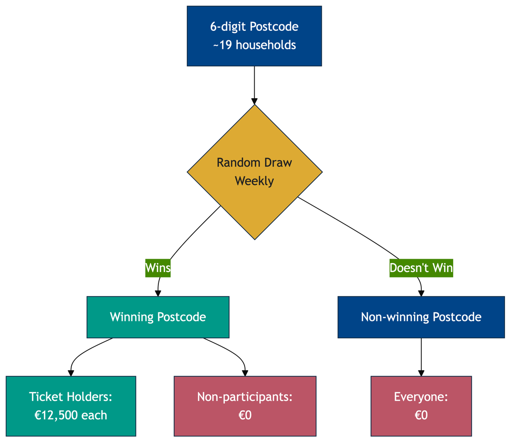

## Random Assignment Creates Four Distinct Groups

### Lottery Participation and Postcode Status Define Treatment

|  |  | Postcode Status |  |
| --- | --- | --- | --- |
|  |  | Non-winning | Winning |
| Lottery Participation | Non-buyer | Control for Veblen n = 878 | Test Veblen Effects n = 477 |
|  | Buyer | Control for Keynes n = 301 | Test Keynes (Winners) n = 223 |

# Valid Counterfactuals Enable Causal Inference

## Control Groups Reveal Counterfactual Outcomes

### Similar Non-Winners Show What Would Have Happened

#### The Identification Challenge

Winners received €13,947 - but what would they have done without it?

#### The Solution

Compare to similar people who didn’t win by pure chance

**The key assumption**: Control group shows what would have happened to winners without the lottery

**The challenge**: Are lottery buyers inherently different from non-buyers?

## Lottery Buyers Differ Marginally from Non-Buyers

### Pre-Existing Differences Require Careful Group Comparisons

Testing across all participants (winners and non-winners combined):

#### Total Consumption Before Lottery

- **$H_{0}$**: $\mu(\text{buyers}) = \mu(\text{non-buyers})$
- **$H_{1}$**: $\mu(\text{buyers}) ≠ \mu(\text{non-buyers})$ [two-sided test]
- **Result**: €987 vs €933, $t = -0.87, p = 0.384$
- **Decision**: Fail to reject $H_{0}$ at $\alpha = 0.05$

#### Happiness Before Lottery

- **$H_{0}$**: $\mu(\text{buyers}) = \mu(\text{non-buyers})$
- **$H_{1}$**: $\mu(\text{buyers}) ≠ \mu(\text{non-buyers})$ [two-sided test]
- **Result**: 6.89 vs 6.72, $t = -1.89, p = 0.059$
- **Decision**: Fail to reject $H_{0}$ at $\alpha = 0.05$ (marginal)

## Buyers Across Postcodes Are Not Statistically Different

### Random Assignment Validates the Keynes Test

**Comparison**: Buyers in winning vs non-winning postcodes (before lottery)

#### Testing Balance in Total Consumption

- **$H_{0}$**: $\mu(\text{buyers, winning}) = \mu(\text{buyers, non-winning})$
- **$H_{1}$**: $\mu(\text{buyers, winning}) \neq \mu(\text{buyers, non-winning})$
- **Test**: Two-sided at $\alpha = 0.05$
- **Result**: €1,058 vs €936, $t = -1.38, p = 0.168$
- **Decision**: Fail to reject $H_{0}$ → Groups are comparable

✓ Valid test for Keynes hypothesis

## Non-Buyers Across Postcodes Are Comparable

### Balance Tests Confirm Valid Peer Effect Analysis

**Comparison**: Non-buyers in winning vs non-winning postcodes (before lottery)

#### Testing Balance in Total Consumption

- **$H_{0}$**: $\mu(\text{non-buyers, winning}) = \mu(\text{non-buyers, non-winning})$
- **$H_{1}$**: $\mu(\text{non-buyers, winning}) \neq \mu(\text{non-buyers, non-winning})$
- **Test**: Two-sided at $\alpha = 0.05$
- **Result**: €898 vs €952, $t = 0.62, p = 0.533$
- **Decision**: Fail to reject $H_{0}$ → Groups are comparable

✓ Valid test for peer effects

# Keynes Theory Receives Partial Support

## Keynes Predicts Windfalls Increase Current Consumption

### Permanent Income Theory Predicts No Effect

#### Formal hypotheses for lottery winners

- **$H_{0}$**: $\mu(\text{total|winner}) = \mu(\text{total|buyer, non-winning})$
  - *Lottery winnings do not affect consumption*
- **$H_{1}$**: $\mu(\text{total|winner}) > \mu(\text{total|buyer, non-winning})$
  - *Lottery winnings increase consumption*
- **Test**: One-sided at $\alpha = 0.05$
- **Comparison groups**: Winners ($n=223$) vs Control buyers ($n=301$)

## Winners Spend €186 More Monthly Than Controls

### Total Consumption Increases Significantly Post-Lottery

#### Total Monthly Consumption

- Winners: €1,181
- Control buyers: €995
- Difference: **+€186**
- Test statistic: t = 2.15
- $p$-value: 0.032

**Decision**: Reject $H_{0}$ at $\alpha = 0.05$

Lottery winners spend €186/month more

**Economic interpretation**: €13,947 windfall → 1.3% monthly increase

## Discretionary and Durable Spending Drive the Increase

### Food Away and Durables Show Largest Effects

| Category | Winners | Control | Difference | $p$-value | Result |
| --- | --- | --- | --- | --- | --- |
| Food at home | €495 | €465 | +€30 | 0.241 | Not significant |
| **Food away** | **€125** | **€84** | **+€41** | **0.004** | **Significant**** |
| Transportation | €214 | €190 | +€24 | 0.393 | Not significant |
| **Other monthly** | **€336** | **€255** | **+€81** | **0.015** | **Significant*** |
| **Durables (6 months)** | **€1,192** | **€659** | **+€533** | **0.009** | **Significant**** |

**Pattern**: Discretionary and durable spending increases, necessities unchanged

# Veblen Effects Appear Only for Visible Goods

## Veblen Theory Predicts Social Influence on Consumption

### Neighbours Should Copy Winners’ Spending Patterns

#### Formal hypotheses for peer effects

- **$H_{0}$**: $\mu(C\mid\text{non-buyer, winning code}) = \mu(C\mid\text{non-buyer, non-winning})$
  - *Neighbours’ winnings do not affect own consumption*
- **$H_{1}$**: $\mu(C\mid\text{non-buyer, winning code}) > \mu(C\mid\text{non-buyer, non-winning})$
  - *Neighbours’ winnings increase own consumption*
- **Test**: One-sided at $\alpha = 0.05$
- **Comparison groups**: Non-buyers near winners ($n=477$) vs Control non-buyers ($n=878$)

## Car Purchases Increase 36% Among Neighbours

### Peer Effects on Car Purchases Exceed Own-Income Effects

**New Car Purchases (Binary Outcome)**

- Non-buyers near winners: 23.6%
- Control non-buyers: 17.3%
- Difference: **+6.3 percentage points**
- Test statistic: $t = 2.34$
- $p$-value: 0.020
- **Decision**: Reject $H_{0}$ at $\alpha = 0.05$

Neighbors show significant effect while winners don’t (1.4pp, $p=0.69$)

## Only Status Goods Show Peer Effects

### Total Consumption and Necessities Remain Unchanged

| Category | Near Winners | Control | Difference | $p$-value | Result |
| --- | --- | --- | --- | --- | --- |
| Total monthly | €1,026 | €1,002 | +€24 | 0.807 | Not significant |
| Food away | €90 | €98 | -€8 | 0.546 | Not significant |
| **New car** | **23.6%** | **17.3%** | **+6.3pp** | **0.020** | **Significant*** |
| **Number of cars** | **1.02** | **0.93** | **+0.09** | **0.010** | **Significant**** |
| Durables | €745 | €806 | -€61 | 0.790 | Not significant |

**Pattern**: Only visible, status goods show peer effects

# Happiness Remains Unchanged for All Groups

## Two Theories Make Different Happiness Predictions

### Absolute Income Predicts Gains, Relative Income Predicts Losses

#### Test A: Absolute Income Effect (Winners)

- **$H_{0}$**: $\mu(\text{happiness|winner}) = \mu(\text{happiness|buyer, non-winning})$
- **$H_{1}$**: $\mu(\text{happiness|winner}) > \mu(\text{happiness|buyer, non-winning})$

#### Test B: Relative Income Effect (Neighbours)

- **$H_{0}$**: $\mu(\text{happiness|non-buyer, winning}) = \mu(\text{happiness|non-buyer, non-winning})$
- **$H_{1}$**: $\mu(\text{happiness|non-buyer, winning}) < \mu(\text{happiness|non-buyer, non-winning})$

Both tests at $\alpha = 0.05$

## Neither Winners Nor Neighbours Report Happiness Changes

### €13,947 Windfall Has Zero Effect on Well-Being

#### Winners’ Happiness (Test A)

- Winners: 7.06
- Control buyers: 7.02
- Difference: +0.04
- $t = 0.25, p = 0.803$
- **Decision**: Fail to reject $H_{0}$

#### Neighbours’ Happiness (Test B)

- Near winners: 6.87
- Control non-buyers: 6.82
- Difference: +0.05
- $t = 0.47, p = 0.641$
- **Decision**: Fail to reject $H_{0}$

Money doesn’t buy happiness (at 6 months)

## Cross-Sectional Correlation Differs from Causal Effect

### Rich People Are Happier But Windfalls Don’t Create Happiness

#### Cross-sectional Evidence

**From the same dataset:**

- Income correlates with happiness
- Coefficient highly significant
- Standard finding globally

#### Experimental Evidence

**From lottery winners:**

- €13,947 windfall
- Zero happiness effect
- No negative spillovers

#### Possible explanations

- Adaptation happens quickly (within 6 months)
- Permanent vs temporary income matters
- **Selection:** happy people earn more vs money makes happy

## Natural Experiment Results Support Mixed Theories

### Keynes and Veblen Find Support, Easterlin Does Not

| Theory | Hypothesis | Key Result | Decision | Conclusion |
| --- | --- | --- | --- | --- |
| **Keynes** | Windfall → ↑Consumption | +€186/month (p=0.032) | Reject $H_{0}$ | ✓ Partial support |
| **Veblen** | Neighbours → ↑Cars | +6.3pp cars (p=0.020) | Reject $H_{0}$ | ✓ Strong support |
| **Easterlin** | Relative income → Happiness | No effect (p>0.6) | Fail to reject $H_{0}$ | ✗ No support |

**Significance levels**: * p<0.05, ** p<0.01, *** p<0.001

# Natural Experiments Transform Correlation into Causation

## Random Assignment Eliminates Selection Bias

### Multiple Control Groups Test Different Mechanisms

#### Identification Strategy

- **Random assignment**: Lottery draw
- **Clear treatment**: €12,500 shock
- **Multiple control groups**: Non-winners, non-buyers
- **Timing**: Survey at 6 months

#### What This Achieves

- **Eliminates selection bias**: Winners chosen randomly
- **Tests multiple theories**: Same shock, different outcomes
- **Identifies spillovers**: Non-participants affected
- **Causal interpretation**

Leveraging postcode-level randomization for individual and social effects

## Windfall Effects Reveal Psychological Patterns

### Mental Accounting and Social Comparison Drive Behavior

#### Consumption Patterns

- **Mental accounting exists**: Windfalls treated differently than regular income
- **Visibility matters**: Social effects only for observable goods (cars)
- **Timing flexibility**: Durables purchases accelerated, necessities unchanged

#### Social Networks

- Magnitude comparable to own-income effects
- Operate through visible status goods

#### Well-being

- Short-run windfalls don’t increase happiness
- No evidence for relative income effects on happiness
- Challenges both absolute and relative income theories

## **Next week:** Regression Analysis Extends These Methods

### OLS Controls for Multiple Factors Simultaneously

**Complete the empirical exercise:**

- Practice interpreting all test results
- Note which hypotheses are one vs two-sided
- Think about economic vs statistical significance

**Key takeaways for econometrics:**

- Natural experiments provide causal identification, when valid counterfactuals exist
- Effect sizes matter, not just significance

**Next week**: Introduction to regression analysis - from t-tests to OLS